# EBV differential expression analysis

# Introduction

The key question to explore is to understand how does dRdZ affects differentiation compared to how does EBV affects differentiation.

## Brief explanation of the design

We have 3 diff. cell lines: EBV, EBV- (NOKS) and EBV-dRdZ and for all of them we tested which genes are differentially expressed by applying a MC treatment, i.e. in total we have 6 different combinations between cell lines and treatments applied. The EBV and EBV- samples were generated independently twice by two labs.

When testing for diff. expressed genes, we ignored genes without expression. Therefore, only genes that were tested for diff. expression in all samples were considered. In total there are 16065 genes.

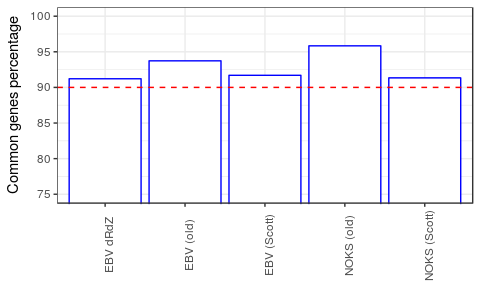

# Definitions

We are going to define as:

- $X$ covariates associated to the EBV- cell line
- $Y$ covariates associated to the EBV cell line
- $Z$ covariates associated to the EBV-dRdZ cell line

#### Expression TPM distribution by condition

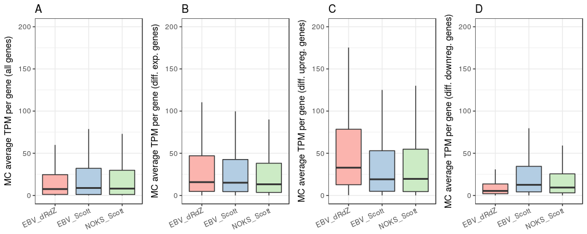

| Cell | DiffExp | Upreg | Downreg | DE_med_TPM | UR_medTPM | DR_medTPM |
| --- | --- | --- | --- | --- | --- | --- |
| EBV_dRdZ | 3282 | 1934 | 1348 | 15.75836 | 32.84268 | 5.254012 |
| EBV_Scott | 6525 | 3235 | 3290 | 15.08000 | 18.64750 | 12.707500 |
| NOKS_Scott | 8879 | 4420 | 4459 | 13.20250 | 19.58000 | 9.347500 |

From the fig. above, it can be seen that the TPM in the EBV dRdZ cell lines is increasing more than in the other cell lines. But that may be an artifact caused by the fact that there are less diff. expressed genes in the EBV dRdZ sample than in the other two cell lines. However, there are 2192 genes that are differentially expressed in the 3 cell lines.

| Set | All | Upreg | Downreg |
| --- | --- | --- | --- |
| 100 | 600 | 409 | 371 |
| 010 | 429 | 221 | 225 |
| 110 | 87 | 39 | 33 |
| 001 | 2467 | 1252 | 1313 |
| 101 | 403 | 193 | 114 |
| 011 | 3817 | 1682 | 2202 |
| 111 | 2192 | 1293 | 830 |

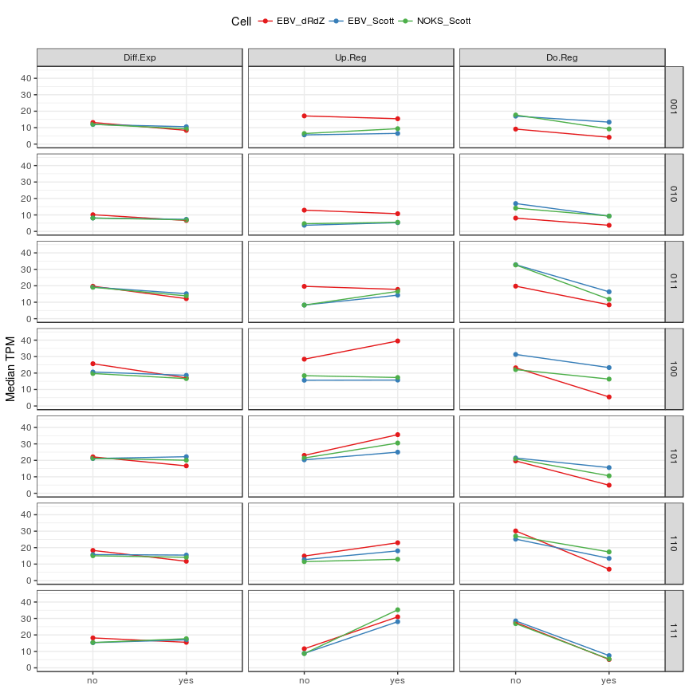

In the plot above, the horizontal panels divide by the genes considered by their expression type (either all diff. expressed genes together or only up/down regulated genes); the verical panels denote the binary code of the diff. expressed genes considered by cell. For example, `101` means consider diff. expressed genes by the MC treatment in the EBV.dRdZ and EBV- (NOKS) cell lines.